# Traffic Sign Classifier

## Convolutional Neural Network Approach

In the project below, a convolutional neural network is constructed to classify a series of German Traffic Signs.

## Load The Data

```python
# Load pickled data
import pickle

training_file = '../Sign-Data/train.p'
validation_file = '../Sign-Data/valid.p'
testing_file = '../Sign-Data/test.p'

with open(training_file, mode='rb') as f:
    train = pickle.load(f)
with open(validation_file, mode='rb') as f:
    valid = pickle.load(f)
with open(testing_file, mode='rb') as f:
    test = pickle.load(f)

X_train, y_train = train['features'], train['labels']
X_valid, y_valid = valid['features'], valid['labels']
X_test, y_test = test['features'], test['labels']
```

## Dataset Summary & Exploration

The pickled data is a dictionary with 4 key/value pairs:

- `'features'` is a 4D array containing raw pixel data of the traffic sign images, (num examples, width, height, channels).
- `'labels'` is a 1D array containing the label/class id of the traffic sign. The file `signnames.csv` contains id -> name mappings for each id.
- `'sizes'` is a list containing tuples, (width, height) representing the original width and height the image.
- `'coords'` is a list containing tuples, (x1, y1, x2, y2) representing coordinates of a bounding box around the sign in the image.

### Summary of Data

```python
# Number of training examples
n_train = len(X_train)

# Number of validation examples
n_validation = len(X_valid)

# Number of testing examples.
n_test = len(X_test)

# What's the shape of an traffic sign image?
image_shape = X_train[0].shape

# How many unique classes/labels there are in the dataset.
n_classes = max(y_train)+1

print("Number of training examples =", n_train)
print("Number of testing examples =", n_test)
print("Image data shape =", image_shape)
print("Number of classes =", n_classes)
```

```
Number of training examples = 34799
Number of testing examples = 12630
Image data shape = (32, 32, 3)
Number of classes = 43
```

### Example Training Images

A sample sign has been provided below from each training category

[figure not shown]

```python
import matplotlib.pyplot as plt
from mpl_toolkits.axes_grid1 import ImageGrid
import numpy as np
from sklearn.utils import shuffle

fig = plt.figure(figsize=(15., 15.))
grid = ImageGrid(fig, 111,  # similar to subplot(111)
                 nrows_ncols=(5, 9),  # creates 2x2 grid of axes
                 axes_pad=0.1,  # pad between axes in inch.
                 )
imgs = []
for i in range(n_classes):
    ind = np.where(y_train==i)
    imgs.append(X_train[ind[0][0]])

for ax, im in zip(grid, imgs):
    ax.imshow(im)

plt.show()
```

### Training Example Distribution

The number of training examples for each category has been plotted below. It is clearly not uniform, and as a result we can expect better performance of the model on some signs over others.

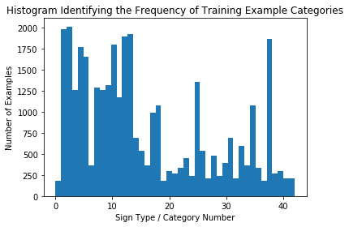

```python
import matplotlib.mlab as mlab

fig, ax = plt.subplots()

# the histogram of the data
n, bins, patches = ax.hist(y_train, n_classes)

# add a 'best fit' line
ax.set_xlabel('Sign Type / Category Number')
ax.set_ylabel('Number of Examples')
ax.set_title('Histogram Identifying the Frequency of Training Example Categories')

# Tweak spacing to prevent clipping of ylabel
fig.tight_layout()
plt.show()
%matplotlib inline
```

## Model Architecture Design

### Pre-process the Data Set (normalization, grayscale, etc.)

Minimally, the image data should be normalized so that the data has mean zero and equal variance. For image data, `(pixel - 128)/ 128` is a quick way to approximately normalize the data.

The data is also converted into grayscale.

```python
import cv2

def preprocess_img(imgset):
    # Make the images in the training set all grayscale
    outset = []
    for ind in range(len(imgset)):
        outset.append(cv2.cvtColor(imgset[ind], cv2.COLOR_RGB2GRAY))
    outset = np.array(outset)
    outset = np.asarray(outset, dtype=int)[...,None]

    # Randomise and Normalise the image pixel data
    outset = np.float32((outset + -128)/128)

    return outset

X_processed = preprocess_img(X_train)
X_valid = preprocess_img(X_valid)
```

### Model Architecture

A basic LeNet architecture was used to solve this problem, with further optimisations and improvements listed below.

```python
# Hyperparameters
EPOCHS = 20
BATCH_SIZE = 250
RATE = 0.002
KEEP_PROB = 0.85
TEST = 0 #Determines whether dropout is enabled
```

```python
import tensorflow as tf
from tensorflow.contrib.layers import flatten

def LeNet(x):
    # Arguments used for tf.truncated_normal, randomly defines variables for the weights and biases for each layer
    mu = 0
    sigma = 0.1

    # Layer 1: Convolutional. Input = 32x32x3. Output = 28x28x6.
    conv_layer1W = tf.Variable(tf.truncated_normal([5,5,1,6], mean=mu, stddev=sigma))
    conv_layer1B = tf.Variable(tf.zeros(6))
    conv_layer1 = tf.nn.conv2d(x, conv_layer1W, strides=[1,1,1,1], padding='VALID') + conv_layer1B

    # Activation.
    conv_layer1Act = tf.nn.relu(conv_layer1)

    # Pooling. Input = 28x28x6. Output = 14x14x6.
    conv_layer1Act = tf.nn.max_pool(conv_layer1Act, ksize=[1,2,2,1], strides=[1,2,2,1], padding='VALID')

    # Layer 2: Convolutional. Output = 10x10x16.
    conv2_W = tf.Variable(tf.truncated_normal([5,5,6,16], mean=mu, stddev=sigma))
    conv2_B = tf.Variable(tf.zeros(16))
    conv2 = tf.nn.conv2d(conv_layer1Act, conv2_W, strides=[1,1,1,1], padding='VALID') + conv2_B

    # Activation.
    conv2 = tf.nn.relu(conv2)

    # Pooling. Input = 10x10x16. Output = 5x5x16.
    conv2 = tf.nn.max_pool(conv2, ksize=[1, 2, 2, 1], strides=[1, 2, 2, 1], padding='VALID')

    # Flatten. Input = 5x5x16. Output = 400.
    fc0   = flatten(conv2)

    # Layer 3: Fully Connected. Input = 400. Output = 120.
    fc1_W = tf.Variable(tf.truncated_normal(shape=(400, 120), mean = mu, stddev = sigma))
    fc1_b = tf.Variable(tf.zeros(120))
    fc1   = tf.matmul(fc0, fc1_W) + fc1_b

    # Activation.
    fc1    = tf.nn.relu(fc1)

    # Dropout layer for fully connected layer 1
    if TEST == 0:
        fc1 = tf.nn.dropout(fc1, KEEP_PROB)

    # Layer 4: Fully Connected. Input = 120. Output = 84.
    fc2_W  = tf.Variable(tf.truncated_normal(shape=(120, 84), mean = mu, stddev = sigma))
    fc2_b  = tf.Variable(tf.zeros(84))
    fc2    = tf.matmul(fc1, fc2_W) + fc2_b

    # Activation.
    fc2    = tf.nn.relu(fc2)

    # Dropout layer for fully connected layer 2
    if TEST == 0:
        fc2 = tf.nn.dropout(fc2, KEEP_PROB)

    # Layer 5: Fully Connected. Input = 84. Output = n_classes.
    fc3_W  = tf.Variable(tf.truncated_normal(shape=(84, n_classes), mean = mu, stddev = sigma))
    fc3_b  = tf.Variable(tf.zeros(n_classes))
    logits = tf.matmul(fc2, fc3_W) + fc3_b

    return logits
```

### Train and Validate the Model

In the following section, the model was trained and validated on the validation set. The dropout layers added in the model helped to prevent overfit, as seen in the accuracy parameters below.

```python
x = tf.placeholder(tf.float32, (None, 32, 32, 1))
y = tf.placeholder(tf.int32, (None))
one_hot_y = tf.one_hot(y, n_classes)
```

```python
logits = LeNet(x)
cross_entropy = tf.nn.softmax_cross_entropy_with_logits(labels=one_hot_y, logits=logits)
loss_operation = tf.reduce_mean(cross_entropy)
optimizer = tf.train.AdamOptimizer(learning_rate = RATE)
training_operation = optimizer.minimize(loss_operation)
```

```python
correct_prediction = tf.equal(tf.argmax(logits, 1), tf.argmax(one_hot_y, 1))
accuracy_operation = tf.reduce_mean(tf.cast(correct_prediction, tf.float32))
saver = tf.train.Saver()

def evaluate(X_data, y_data):
    num_examples = len(X_data)
    total_accuracy = 0
    sess = tf.get_default_session()
    for offset in range(0, num_examples, BATCH_SIZE):
        batch_x, batch_y = X_data[offset:offset+BATCH_SIZE], y_data[offset:offset+BATCH_SIZE]
        accuracy = sess.run(accuracy_operation, feed_dict={x: batch_x, y: batch_y})
        total_accuracy += (accuracy * len(batch_x))
    return total_accuracy / num_examples
```

```python
with tf.Session() as sess:
    sess.run(tf.global_variables_initializer())
    num_examples = len(X_train)

    print("Training...")
    print()
    for i in range(EPOCHS):
        X_processed, y_train = shuffle(X_processed, y_train)
        for offset in range(0, num_examples, BATCH_SIZE):
            end = offset + BATCH_SIZE
            batch_x, batch_y = X_processed[offset:end], y_train[offset:end]
            sess.run(training_operation, feed_dict={x: batch_x, y: batch_y})

        validation_accuracy = evaluate(X_valid, y_valid)
        print("EPOCH {} ...".format(i+1))
        print("Validation Accuracy = {:.3f}".format(validation_accuracy))
        test_accuracy = evaluate(X_processed, y_train)
        print("Train Accuracy = {:.3f}".format(test_accuracy))
        print()

    saver.save(sess, './TrainingData/lenet')
    print("Model saved")
```

```
Training...

EPOCH 1 ...
Validation Accuracy = 0.661
Train Accuracy = 0.719

EPOCH 2 ...
Validation Accuracy = 0.823
Train Accuracy = 0.875

EPOCH 3 ...
Validation Accuracy = 0.855
Train Accuracy = 0.921

EPOCH 4 ...
Validation Accuracy = 0.883
Train Accuracy = 0.949

EPOCH 5 ...
Validation Accuracy = 0.885
Train Accuracy = 0.957

EPOCH 6 ...
Validation Accuracy = 0.899
Train Accuracy = 0.966

EPOCH 7 ...
Validation Accuracy = 0.912
Train Accuracy = 0.972

EPOCH 8 ...
Validation Accuracy = 0.914
Train Accuracy = 0.977

EPOCH 9 ...
Validation Accuracy = 0.918
Train Accuracy = 0.980

EPOCH 10 ...
Validation Accuracy = 0.919
```

[output cut: 28 more lines]

```
Train Accuracy = 0.989

EPOCH 18 ...
Validation Accuracy = 0.927
Train Accuracy = 0.991

EPOCH 19 ...
Validation Accuracy = 0.930
Train Accuracy = 0.991

EPOCH 20 ...
Validation Accuracy = 0.937
Train Accuracy = 0.992

Model saved
```

### Check the Model on the Test Set

The model trained above was then run on the test set, to determine its accuracy.

```python
X_test = preprocess_img(X_test)
with tf.Session() as sess:
    # Load Trained Model
    TEST = 1
    saver.restore(sess, "./TrainingData/lenet")
    test_acc = evaluate(X_test, y_test)
    print("Test Accuracy = {:.3f}".format(test_acc))
```

```
INFO:tensorflow:Restoring parameters from ./TrainingData/lenet
Test Accuracy = 0.917
```

## Step 3: Test a Model on New Images

To give yourself more insight into how your model is working, download at least five pictures of German traffic signs from the web and use your model to predict the traffic sign type.

You may find `signnames.csv` useful as it contains mappings from the class id (integer) to the actual sign name.

### Load and Output the Images

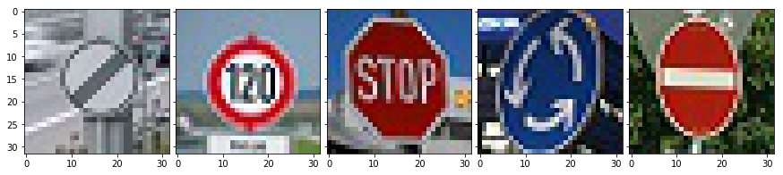

```python
img = []
val = []

# Load in each image and its corresponding label
img.append(plt.imread('test_images/nn1.jpg'))
val.append(32)
img.append(plt.imread('test_images/nn2.jpg'))
val.append(8)
img.append(plt.imread('test_images/nn3.jpg'))
val.append(14)
img.append(plt.imread('test_images/nn4.jpg'))
val.append(40)
img.append(plt.imread('test_images/nn5.jpg'))
val.append(17)

# Print the images
fig = plt.figure(figsize=(15., 15.))
grid = ImageGrid(fig, 111,  # similar to subplot(111)
                 nrows_ncols=(1, 5),  # creates 2x2 grid of axes
                 axes_pad=0.1,  # pad between axes in inch.
                 )
for ax, im in zip(grid, img):
    ax.imshow(im)
plt.show()

# Preprocess the images
img = preprocess_img(img)
```

### Predict the Sign Type for Each Image

```python
with tf.Session() as sess:
    # Load Trained Model
    TEST = 1
    saver.restore(sess, "./TrainingData/lenet")
    test_acc = evaluate(img, val)
    print("Test Accuracy = {:.3f}".format(test_acc))
    a = tf.Print(one_hot_y, [one_hot_y], "boobies")
    b = tf.add(a,a)
```

```
INFO:tensorflow:Restoring parameters from ./TrainingData/lenet
Test Accuracy = 1.000
```

### Analyze Performance

```python
### Calculate the accuracy for these 5 new images.
### For example, if the model predicted 1 out of 5 signs correctly, it's 20% accurate on these new images.
np.set_printoptions(precision=6, suppress=True)
with tf.Session() as sess:
    saver.restore(sess, "./TrainingData/lenet")
    softmax = sess.run(tf.nn.softmax(logits), feed_dict={x: img})
    max5 = sess.run(tf.nn.top_k(tf.constant(softmax), k=5))
    for pred in range(len(max5[0])):
        print("Image ", pred + 1, " Probabilities and Corresponding Indices:")
        print(max5[0][pred])
        print(max5[1][pred])
        print("")
```

```
INFO:tensorflow:Restoring parameters from ./TrainingData/lenet
Image  1  Probabilities and Corresponding Indices:
[0.99993  0.000056 0.000006 0.000004 0.000004]
[32 38  6  0 41]

Image  2  Probabilities and Corresponding Indices:
[0.999767 0.000233 0.       0.       0.      ]
[ 8  7  1  2 40]

Image  3  Probabilities and Corresponding Indices:
[0.948699 0.051301 0.       0.       0.      ]
[38 14 22 17 34]

Image  4  Probabilities and Corresponding Indices:
[0.998343 0.001656 0.       0.       0.      ]
[40 11 12  6 42]

Image  5  Probabilities and Corresponding Indices:
[1. 0. 0. 0. 0.]
[17 34 33  9 26]
```

# Conclusion

A full writeup and reflection of this project can be found in the github repository.